# Vertical Scaling

This is a notebook for the design and implementation of educational assessment vertical scaling.

```r
library(devtools)
library(plink)
library(psych)
library(janitor)
library(tidyverse)
library(mirt)
library(parallel) # for est_abilities_parallel function
library(ggthemes)

options(digits = 5)

# And load functions for MLE ability estimation
# devtools::source_url("https://raw.githubusercontent.com/scottfrohn/scott_public/main/estimator_functions.R")
```

# Unidimensional Examples

These examples demonstrate vertical scaling of item parameters.

## Two Groups, 3PL

**KB04 / Kolen - Brennan (2004)**: This (unidimensional) dataset includes three parameter logistic model (3PL) item parameter estimates for two groups. The Form X items are from a “new” form and the Form Y items are from an “old” form. The data are listed in Table 6.5 in Test Equating, Scaling, and Linking (2nd ed.). There are 12 common items between the two forms.

### Load and Examine Data

Load the `KB04` dataset from [`plink`](https://cran.r-project.org/web/packages/plink/plink.pdf) package

```r
KB04 <- KB04

KB04$pars
```

|  | discrimination | difficulty | asymptote |
| --- | --- | --- | --- |
| 1 | 0.5496 | -1.7960 | 0.1751 |
| 2 | 0.7891 | -0.4796 | 0.1165 |
| 3 | 0.4551 | -0.7101 | 0.2087 |
| 4 | 1.4443 | 0.4833 | 0.2826 |
| 5 | 0.9740 | -0.1680 | 0.2625 |
| 6 | 0.5839 | -0.8567 | 0.2038 |
| 7 | 0.8604 | 0.4546 | 0.3224 |
| 8 | 1.1445 | -0.1301 | 0.2209 |
| 9 | 0.7544 | 0.0212 | 0.1600 |
| 10 | 0.9170 | 1.0139 | 0.3648 |

[output cut: 26 more lines]

|  | discrimination | difficulty | asymptote |
| --- | --- | --- | --- |
| 37 | 0.8704 | -1.4507 | 0.1576 |
| 38 | 0.4628 | -0.4070 | 0.1094 |
| 39 | 0.4416 | -1.3349 | 0.1559 |
| 40 | 0.5448 | -0.9017 | 0.1381 |
| 41 | 0.6200 | -1.4865 | 0.2114 |
| 42 | 0.5730 | -1.3210 | 0.1913 |
| 43 | 1.1752 | 0.0691 | 0.2947 |
| 44 | 0.4450 | 0.2324 | 0.2723 |
| 45 | 0.5987 | -0.7098 | 0.1177 |
| 46 | 0.8479 | -0.4253 | 0.1445 |

[output cut: 26 more lines]

```r
KB04$common
```

```
      form.x form.y
 [1,]      3      3
 [2,]      6      6
 [3,]      9      9
 [4,]     12     12
 [5,]     15     15
 [6,]     18     18
 [7,]     21     21
 [8,]     24     24
 [9,]     27     27
[10,]     30     30
[11,]     33     33
[12,]     36     36
```

### Vertical Scaling

Single format item parameters for multiple groups (2)

```r
# Create irt.pars object with two groups (all dichotomous items)
kb04.pm <- as.poly.mod(36)  # Create a poly.mod object with 36 items
                            # Default model = "drm" for dichotomous responses model
                            # All items are of the same model family (drm)

kbo4.irt.pars <- as.irt.pars(       # Turn values into an `irt.pars` object
  x = KB04$pars,                    # An object of class `irt.pars` with multiple groups
  common = KB04$common,             # Matrix of common items between the groups
  cat = list(rep(2,36),rep(2,36)),  # Number of response categories for each item in the datasets
                                    # Two response categories
  poly.mod = list(kb04.pm, kb04.pm) # Lists the poly.mod objects that defines the models for each item (all are the same, 36 'drm' items)
                             )

# rescale the item parameters using the Mean/Sigma linking constants,
# and exclude item 27 from the common item set
kb04.out <- plink(kbo4.irt.pars,
             rescale = "MS",        # Transform parameters to the base scale, using Mean/Sigma (Mean/SD) method
             base.grp = 2,          # The base scale is group 2 (form.y)
             D = 1.7,               # The scaling constant to transform the logistic model; D=1.7 is equivalent to the normal ogive model
             exclude = list(27,NA)) # Excludes item 27 from the linking process

# And get the new item parameters.
kb04.pars.out <- link.pars(kb04.out)
```

### Examine Scaling Results

Now let’s use a summary of the scaling.

```r
summary(kb04.out, descrip = TRUE)
```

```
-------  group1/group2*  -------
Linking Constants
```

|  | A | B |
| --- | --- | --- |
| Mean/Mean | 1.144959 | -0.478967 |
| Mean/Sigma | 1.176074 | -0.504188 |
| Haebara | 1.088361 | -0.441590 |
| Stocking-Lord | 1.097363 | -0.464035 |

```
Common Item Descriptive Statistics

Model: 3PL
Number of Items: 11
```

|  | a | b | c |
| --- | --- | --- | --- |
| N Pars: | 11.000000 | 11.000000 | 11.000000 |
| Mean: To | 0.770809 | 0.449127 | 0.149773 |
| Mean: From | 0.882545 | 0.810591 | 0.155864 |
| SD: To | 0.285828 | 1.293511 | 0.076785 |
| SD: From | 0.366505 | 1.099855 | 0.072778 |

```
NANA
```

What this output tells us:

1. The 11 common items were all 3pl calibrated
2. The Slope (A) and Intercept (B) parameters for the different types of linear scaling methods are presented. Since we used `rescale = 'MS'`, our parameters are in the row marked `Mean/Sigma` which can be used to rescale the 3pl item parameters for Form X (since Form Y was our base form). These parameter are: – A (slope) = 1.176074 – B (intercept) = -0.504188
3. Because these are the linear differences in common items, we can somewhat interpret the intercept (about -0.50), to indicate that that the group that took Form X are on average, about 1/2 a Standard Deviation lower in ability than the group that took Form Y
4. The last table shows the descriptive stats of parameters for the common items for Form Y (To) and Form X (From). Note the SD calculated here is the population SD (so `sd()` will return number slightly off)

### Verify Scaling Results

Let’s check those item parameters from the fianl scaling object (`kb04.out`). Note that Form Y (`group2`) params should be the same, and Form X (`group1`) params will be different.

#### Form Y

Since they shouldn’t have changed, let’s check Form Y first

```r
(form.y.params <- KB04$pars$form.y %>%
  rename(a.before = "discrimination",
         b.before = "difficulty",
         c.before = "asymptote") %>%
  bind_cols(kb04.pars.out$group2 %>%
              as.data.frame() %>%
              setNames(c("a.after","b.after","c.after"))) %>%
   mutate(item = seq(1:nrow(kb04.pars.out$group2)),
          common = ifelse(item %in% data.frame(kb04.out$pars@common)[,2],
                          1,0)) %>%
   relocate(item, common, a.before, a.after, b.before, b.after, c.before, c.after)
)
```

|  | item | common | a.before | a.after | b.before | b.after | c.before | c.after |
| --- | --- | --- | --- | --- | --- | --- | --- | --- |
| 37 | 1 | 0 | 0.8704 | 0.8704 | -1.4507 | -1.4507 | 0.1576 | 0.1576 |
| 38 | 2 | 0 | 0.4628 | 0.4628 | -0.4070 | -0.4070 | 0.1094 | 0.1094 |
| 39 | 3 | 1 | 0.4416 | 0.4416 | -1.3349 | -1.3349 | 0.1559 | 0.1559 |
| 40 | 4 | 0 | 0.5448 | 0.5448 | -0.9017 | -0.9017 | 0.1381 | 0.1381 |
| 41 | 5 | 0 | 0.6200 | 0.6200 | -1.4865 | -1.4865 | 0.2114 | 0.2114 |
| 42 | 6 | 1 | 0.5730 | 0.5730 | -1.3210 | -1.3210 | 0.1913 | 0.1913 |
| 43 | 7 | 0 | 1.1752 | 1.1752 | 0.0691 | 0.0691 | 0.2947 | 0.2947 |
| 44 | 8 | 0 | 0.4450 | 0.4450 | 0.2324 | 0.2324 | 0.2723 | 0.2723 |
| 45 | 9 | 1 | 0.5987 | 0.5987 | -0.7098 | -0.7098 | 0.1177 | 0.1177 |
| 46 | 10 | 0 | 0.8479 | 0.8479 | -0.4253 | -0.4253 | 0.1445 | 0.1445 |

[output cut: 26 more lines]

```r
# Check the number of items that have different before and after parameters
form.y.params %>%
  mutate(a.diff = a.before - a.after, # Difference between the params before and after scaling
         b.diff = b.before - b.after,
         c.diff = c.before - c.after) %>%
  select(a.diff, b.diff, c.diff) %>%
  summarise(a_differences = sum(a.diff != 0),
            b_differences = sum(b.diff != 0),
            c_differences = sum(c.diff != 0)) %>%
  t() %>% data.frame("N.items" = .)
```

|  | N.items |
| --- | --- |
| a_differences | 0 |
| b_differences | 0 |
| c_differences | 0 |

The first table shows a side-by-side comparison of parameters ‘before’ and ‘after’ scaling for each item. Looks like nothing has changed (which is what we expect). The next table provides a summary of the number of different parameters, which we can confirm is 0 for `a`, `b`, and `c`. Looks good, let’s check Form X now.

#### Form X

So let’s use that those linear scaling parameters to manually rescale the original Form X params and compare against the output from `plink`.

Note that the parameter transformation equations are different for each parameter:

1. Discrimination (a): a’ = a / slope
2. Difficulty (b): b’ = b * slope + intercept
3. Asymptote (c): ’c = c

```r
# Get the slope and intercept from the scaling output. If we wanted to, we could change the '$MS' to '$MM', '$HB', or '$SL' to access the other linear parameters for the other 3 scaling methods.
x.slope <- kb04.out$link@constants$MS[1]
x.intercept <- kb04.out$link@constants$MS[2]

(form.x.params <- KB04$pars$form.x %>%
  rename(a.before = "discrimination",
         b.before = "difficulty",
         c.before = "asymptote") %>%
  bind_cols(kb04.pars.out$group1 %>%
              as.data.frame() %>%
              setNames(c("a.after","b.after","c.after"))) %>%
   mutate(item = seq(1:nrow(kb04.pars.out$group1)),
          common = ifelse(item %in% data.frame(kb04.out$pars@common)[,1],
                          1,0)) %>%
   relocate(item, common, a.before, a.after, b.before, b.after, c.before, c.after)
)
```

|  | item | common | a.before | a.after | b.before | b.after | c.before | c.after |
| --- | --- | --- | --- | --- | --- | --- | --- | --- |
| 1 | 1 | 0 | 0.5496 | 0.46732 | -1.7960 | -2.616417 | 0.1751 | 0.1751 |
| 2 | 2 | 0 | 0.7891 | 0.67096 | -0.4796 | -1.068233 | 0.1165 | 0.1165 |
| 3 | 3 | 1 | 0.4551 | 0.38697 | -0.7101 | -1.339318 | 0.2087 | 0.2087 |
| 4 | 4 | 0 | 1.4443 | 1.22807 | 0.4833 | 0.064209 | 0.2826 | 0.2826 |
| 5 | 5 | 0 | 0.9740 | 0.82818 | -0.1680 | -0.701768 | 0.2625 | 0.2625 |
| 6 | 6 | 1 | 0.5839 | 0.49648 | -0.8567 | -1.511731 | 0.2038 | 0.2038 |
| 7 | 7 | 0 | 0.8604 | 0.73159 | 0.4546 | 0.030455 | 0.3224 | 0.3224 |
| 8 | 8 | 0 | 1.1445 | 0.97315 | -0.1301 | -0.657195 | 0.2209 | 0.2209 |
| 9 | 9 | 1 | 0.7544 | 0.64146 | 0.0212 | -0.479255 | 0.1600 | 0.1600 |
| 10 | 10 | 0 | 0.9170 | 0.77971 | 1.0139 | 0.688233 | 0.3648 | 0.3648 |

[output cut: 26 more lines]

```r
form.x.params %>%
  mutate(a.calc = a.before / x.slope,
         b.calc = b.before * x.slope + x.intercept,
         c.calc = c.before,
         a.diff = a.before - a.after, # Difference between the params before and after scaling
         b.diff = b.before - b.after,
         c.diff = c.before - c.after,
         a.calc.diff = a.calc - a.after,
         b.calc.diff = b.calc - b.after,
         c.calc.diff = c.calc - c.after) %>%
  select(a.diff, b.diff, c.diff, a.calc.diff, b.calc.diff, c.calc.diff) %>%
  summarise(a_differences = sum(a.diff != 0),
            b_differences = sum(b.diff != 0),
            c_differences = sum(c.diff != 0),
            a_calc_diffs = sum(a.calc.diff != 0),
            b_calc_diffs = sum(b.calc.diff != 0),
            c_calc_diffs = sum(c.calc.diff != 0)) %>%
  t() %>% data.frame("N.items" = .)
```

|  | N.items |
| --- | --- |
| a_differences | 36 |
| b_differences | 36 |
| c_differences | 0 |
| a_calc_diffs | 0 |
| b_calc_diffs | 0 |
| c_calc_diffs | 0 |

Again, the first table shows a side-by-side comparison of parameters ‘before’ and ‘after’ scaling for each item. Looks like the `a`’s and `b`’s have changed, but `c`’s have not (as expected).

The second table shows that:

- All (36) of the `a` parameters are different after scaling.
- All (36) of the `b` parameters are different after scaling.
- None of the `c` parameters are different after scaling.
- None of the calculated `a`, `b`, and `c` parameters are different than the `plink` scaled ones. Our calculated parameters using the “Mean/Sigma” values produce the same results.

### Scoring Results

Now that we’ve confirmed the scaling results, let’s simulate abilities and check the impact of scaling.

#### Simulate Ability

Step 1: Simulate ability levels

```r
# 1. Simulate ability levels
n_test_takers <- 1000

# Group x is lower ability (this will be evident when creating response patterns, no need to change the distribution)
set.seed(123)
theta.x <- rnorm(n_test_takers)
# Group y is higher ability
set.seed(234)
theta.y <- rnorm(n_test_takers)

describe(theta.x) %>%
  bind_rows(describe(theta.y))
```

|  | vars | n | mean | sd | median | trimmed | mad | min | max | range | skew | kurtosis | se |
| --- | --- | --- | --- | --- | --- | --- | --- | --- | --- | --- | --- | --- | --- |
| X1...1 | 1 | 1000 | 0.02 | 0.99 | 0.01 | 0.01 | 0.96 | -2.81 | 3.24 | 6.05 | 0.07 | -0.08 | 0.03 |
| X1...2 | 1 | 1000 | -0.02 | 0.98 | 0.03 | -0.01 | 0.96 | -3.04 | 3.10 | 6.13 | -0.08 | 0.01 | 0.03 |

Step 2: Generate response data based on our 3pl model

```r
set.seed(345) # for rbinom

generate_responses_3pl <- function(params, theta) {
  a <- params$discrimination
  b <- params$difficulty
  c <- params$asymptote
  n_items <- length(a)
  responses <- matrix(0, nrow = length(theta), ncol = n_items)

  for (i in 1:length(theta)) {
    for (j in 1:n_items) {
      prob <- c[j] + (1 - c[j]) / (1 + exp(-a[j] * (theta[i] - b[j])))
      responses[i, j] <- rbinom(1, 1, prob)
    }
  }
  return(responses)
}

# Generate responses for both forms
responses.x <- generate_responses_3pl(KB04$pars$form.x, theta.x)
responses.y <- generate_responses_3pl(KB04$pars$form.y, theta.y)
```

- `x.old` are the simulated Form X response data, with the original Form X item parameters
- `x.new` are the simulated Form X response data, with the New Form X item parameters
- `y` are the simulated Form Y response data, with the Form Y item parameters

```r
x.ability.old <- est_abilities_parallel(responses.x,
                                        as = KB04$pars$form.x$discrimination,
                                        bs = KB04$pars$form.x$difficulty,
                                        cs = KB04$pars$form.x$asymptote,
                                        method = "EAP"
                                        )

x.ability.new <- est_abilities_parallel(responses.x,
                                        as = kb04.pars.out$group1[,1],
                                        bs = kb04.pars.out$group1[,2],
                                        cs = kb04.pars.out$group1[,3],
                                        method = "EAP"
                                        )

y.ability <- est_abilities_parallel(responses.y,
                                    as = kb04.pars.out$group2[,1],
                                    bs = kb04.pars.out$group2[,2],
                                    cs = kb04.pars.out$group2[,3],
                                    method = "EAP"
                                    )
# Combine into single DF
kb04.abilities <- x.ability.old %>%
  mutate(group = "x.old",
         ability_true = theta.x) %>%
  bind_rows(x.ability.new %>%
              mutate(group = "x.new",
         ability_true = theta.x)) %>%
  bind_rows(y.ability %>%
              mutate(group = "y",
         ability_true = theta.y)) %>%
  relocate(ability_true)

lapply(list(kb04.abilities$ability_est[kb04.abilities$group=="x.old"],
            kb04.abilities$ability_est[kb04.abilities$group=="x.new"],
            kb04.abilities$ability_est[kb04.abilities$group=="y"]),
       describe) %>%
  bind_rows %>%
  as.data.frame() %>%
  mutate(group = c("x.old","x.new","y")) %>%
  relocate(group, n, mean, sd, min, max, range, median)
```

|  | group | n | mean | sd | min | max | range | median | vars | trimmed | mad | skew | kurtosis | se |
| --- | --- | --- | --- | --- | --- | --- | --- | --- | --- | --- | --- | --- | --- | --- |
| X1...1 | x.old | 1000 | 0.014433 | 0.85040 | -1.9494 | 2.5704 | 4.5198 | -0.046992 | 1 | -0.021005 | 0.84120 | 0.36789 | -0.24987 | 0.026892 |
| X1...2 | x.new | 1000 | -0.309977 | 0.88223 | -2.3023 | 2.4210 | 4.7233 | -0.395482 | 1 | -0.356549 | 0.85541 | 0.46847 | -0.14773 | 0.027899 |
| X1...3 | y | 1000 | -0.014389 | 0.85327 | -2.1406 | 2.7491 | 4.8897 | -0.017563 | 1 | -0.031397 | 0.89624 | 0.18235 | -0.22509 | 0.026983 |

#### Visualize Accuracy

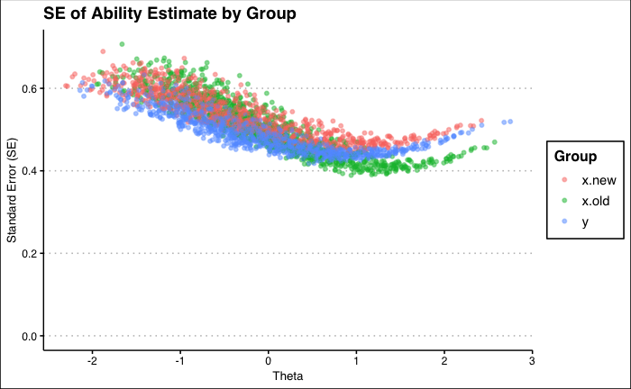

```r
kb04.abilities %>%
  filter(abs(ability_est) <= 6.0) %>%
  ggplot(., aes(x = ability_est, y = ability_est_se, color = group)) +
  geom_jitter(alpha = 0.3) +
  geom_point(alpha = 0.3, size = 1) +
  scale_y_continuous(limits = c(0, NA)) +
  labs(title = "SE of Ability Estimate by Group",
     x = "Theta",
     y = "Standard Error (SE)",
     color = "Group",
     fill = "Group") +
  theme_clean()
```

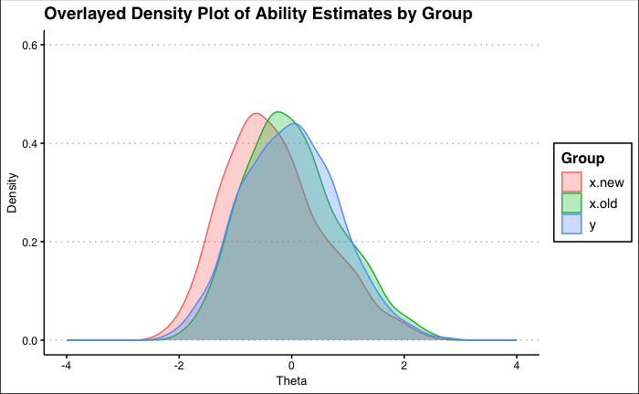

```r
kb04.abilities %>%
  filter(abs(ability_est) <= 6.0) %>%
ggplot(., aes(x = ability_est, color = as.factor(group), fill = as.factor(group))) +
  geom_density(alpha = 0.3) +  # Overlayed density plots with some transparency
  labs(title = "Overlayed Density Plot of Ability Estimates by Group",
       x = "Theta",
       y = "Density",
       color = "Group",
       fill = "Group") +
  scale_x_continuous(limits = c(-4, 4)) +
  scale_y_continuous(limits = c(0, 0.6)) +
  theme_clean()
```

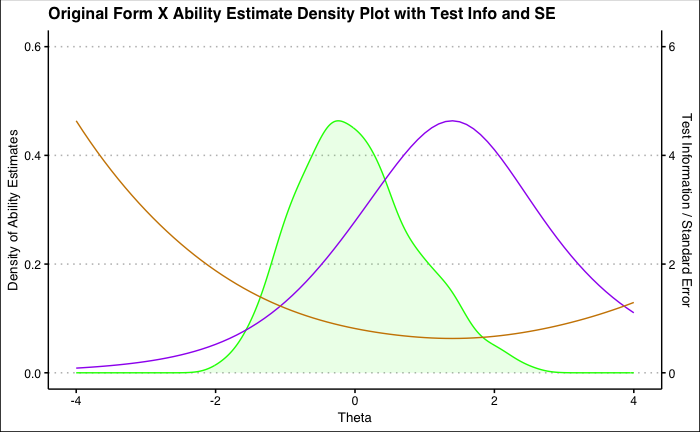

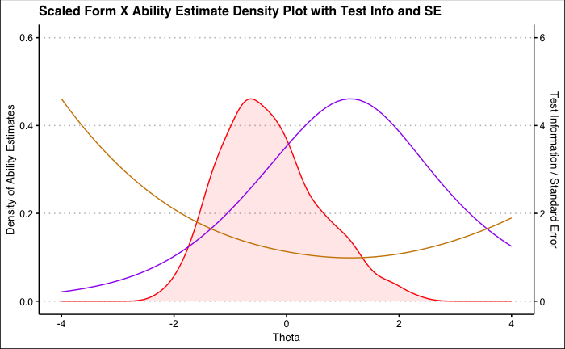

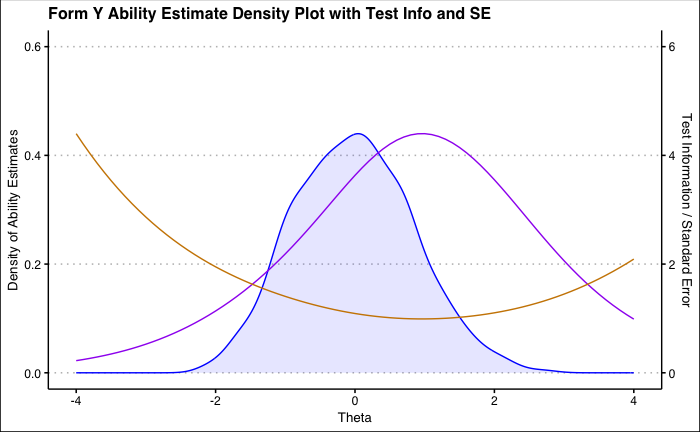

## Six Groups (TK07)

**TK07 / Tong - Kolen (2007)**: This (unidimensional) dataset includes three parameter logistic model (3PL) item parameter estimates from simulated dataset based on items from the 1992 Iowa Test of Basic Skills vocabulary test. The data are for six groups (grades 3-8) with varying numbers of common items between adjacent grades.

Load the `TK07` dataset from [`plink`](https://cran.r-project.org/web/packages/plink/plink.pdf) package.

```r
TK07 <- TK07
```

### Vertical Scaling

```r
# Get the # items items in each
tk07.n.items <- list(nrow(TK07$pars$grade3),
                     nrow(TK07$pars$grade4),
                     nrow(TK07$pars$grade5),
                     nrow(TK07$pars$grade6),
                     nrow(TK07$pars$grade7),
                     nrow(TK07$pars$grade8))

# Create irt.pars object with six groups (all dichotomous items)
tk07.pm <- lapply(tk07.n.items, as.poly.mod)

# Number of response categories for each item in each dataset (all )
tk07.cat <- lapply(tk07.n.items, function(x) rep(2, x))

tk07.irt.pars <- as.irt.pars(# Turn values into an `irt.pars` object
  x = TK07$pars,             # An object of class `irt.pars` with multiple groups
  common = TK07$common,      # Matrix of common items between the groups
  cat = tk07.cat,            # Number of response categories (2) for each item in the dataset
  poly.mod = tk07.pm,        # Lists the poly.mod objects that defines the models for each item
  grp.names = paste0("grade",3:8)
                             )

# rescale the item parameters using the Mean/Sigma linking constants,
tk07.out <- plink(tk07.irt.pars,
             rescale = "MS", # Transform parameters to the base scale, using Mean/Sigma (Mean/SD) method
             base.grp = 1,   # The base scale is Group 1 (default; Grade 3)
             D = 1.7)        # Scaling constant to transform the logistic model; D=1.7 ~~ normal ogive model

tk07.pars.out <- link.pars(tk07.out)
```

### Examine Scaling Results

Now let’s use a summary of the scaling.

```r
summary(tk07.out, descrip = TRUE)
```

```
-------  grade4/grade3*  -------
Linking Constants
```

|  | A | B |
| --- | --- | --- |
| Mean/Mean | 1.047538 | 0.501469 |
| Mean/Sigma | 1.009824 | 0.485654 |
| Haebara | 1.029126 | 0.506470 |
| Stocking-Lord | 1.028393 | 0.514853 |

```
Common Item Descriptive Statistics

Model: 3PL
Number of Items: 13
```

|  | a | b | c |
| --- | --- | --- | --- |
| N Pars: | 13.000000 | 13.000000 | 13.000000 |
| Mean: To | 1.121273 | 0.062215 | 0.168665 |
| Mean: From | 1.174576 | -0.419320 | 0.174462 |
| SD: To | 0.381554 | 0.645446 | 0.051890 |
| SD: From | 0.366924 | 0.639167 | 0.065714 |

```
-------  grade5/grade4  -------
Linking Constants
```

|  | A | B |
| --- | --- | --- |
| Mean/Mean | 1.096315 | 0.363083 |
| Mean/Sigma | 1.106390 | 0.366179 |
| Haebara | 1.090529 | 0.371307 |
| Stocking-Lord | 1.094596 | 0.376521 |

```
Common Item Descriptive Statistics

Model: 3PL
Number of Items: 21
```

|  | a | b | c |
| --- | --- | --- | --- |
| N Pars: | 21.000000 | 21.000000 | 21.000000 |
| Mean: To | 1.031600 | 0.026160 | 0.183080 |
| Mean: From | 1.130959 | -0.307323 | 0.187949 |
| SD: To | 0.257364 | 0.566910 | 0.050228 |
| SD: From | 0.288981 | 0.512396 | 0.042563 |

```
-------  grade6/grade5  -------
Linking Constants
```

|  | A | B |
| --- | --- | --- |
| Mean/Mean | 1.044780 | 0.335868 |
| Mean/Sigma | 0.982909 | 0.338193 |
| Haebara | 1.055488 | 0.312392 |
| Stocking-Lord | 1.067587 | 0.308164 |

```
Common Item Descriptive Statistics

Model: 3PL
Number of Items: 16
```

|  | a | b | c |
| --- | --- | --- | --- |
| N Pars: | 16.000000 | 16.000000 | 16.000000 |
| Mean: To | 1.396931 | 0.375138 | 0.169572 |
| Mean: From | 1.459486 | 0.037587 | 0.158184 |
| SD: To | 0.378975 | 0.357015 | 0.053929 |
| SD: From | 0.417649 | 0.363223 | 0.037159 |

```
-------  grade7/grade6  -------
Linking Constants
```

|  | A | B |
| --- | --- | --- |
| Mean/Mean | 1.054927 | 0.172839 |
| Mean/Sigma | 1.065124 | 0.174310 |
| Haebara | 1.095867 | 0.174173 |
| Stocking-Lord | 1.083968 | 0.173633 |

```
Common Item Descriptive Statistics

Model: 3PL
Number of Items: 24
```

|  | a | b | c |
| --- | --- | --- | --- |
| N Pars: | 24.000000 | 24.000000 | 24.000000 |
| Mean: To | 1.483987 | 0.020580 | 0.178669 |
| Mean: From | 1.565498 | -0.144331 | 0.173834 |
| SD: To | 0.440648 | 0.472816 | 0.047740 |
| SD: From | 0.478056 | 0.443907 | 0.044731 |

```
-------  grade8/grade7  -------
Linking Constants
```

|  | A | B |
| --- | --- | --- |
| Mean/Mean | 1.107232 | 0.111303 |
| Mean/Sigma | 1.077176 | 0.116859 |
| Haebara | 1.092019 | 0.134127 |
| Stocking-Lord | 1.061500 | 0.144610 |

```
Common Item Descriptive Statistics

Model: 3PL
Number of Items: 17
```

|  | a | b | c |
| --- | --- | --- | --- |
| N Pars: | 17.000000 | 17.000000 | 17.000000 |
| Mean: To | 1.584517 | 0.315963 | 0.168705 |
| Mean: From | 1.754428 | 0.184839 | 0.183309 |
| SD: To | 0.442031 | 0.385057 | 0.033025 |
| SD: From | 0.475752 | 0.357469 | 0.038921 |

```
NANA
```

First, let’s simulate response data.

### Scoring Results

#### Simulate Ability

```r
# 1. Simulate ability levels
n_test_takers <- 1000

# Group x is lower ability
set.seed(012)
theta.grade3 <- rnorm(n_test_takers)
set.seed(123)
theta.grade4 <- rnorm(n_test_takers) # + 0.5  # Approx the G3-G4 diff in anchor means
set.seed(234)
theta.grade5 <- rnorm(n_test_takers) # + 0.5 + 0.36  # Plus G4-G5 anchor mean diff
set.seed(345)
theta.grade6 <- rnorm(n_test_takers) # + 0.5 + 0.36 + 0.34  # Plus G5-G6 anchor mean diff
set.seed(456)
theta.grade7 <- rnorm(n_test_takers) # + 0.5 + 0.36 + 0.34 + 0.17  # Plus G6-G7 anchor mean diff
set.seed(567)
theta.grade8 <- rnorm(n_test_takers) # + 0.5 + 0.36 + 0.34 + 0.17 + 0.12  # Plus G7-G8 anchor mean diff

thetas <- list("grade3" = theta.grade3,
               "grade4" = theta.grade4,
               "grade5" = theta.grade5,
               "grade6" = theta.grade6,
               "grade7" = theta.grade7,
               "grade8" = theta.grade8)

lapply(thetas, describe) %>%
  bind_rows %>%
  as.data.frame() %>%
  mutate(group = names(thetas)) %>%
  relocate(group, n, mean, sd, min, max, range, median)
```

|  | group | n | mean | sd | min | max | range | median | vars | trimmed | mad | skew | kurtosis | se |
| --- | --- | --- | --- | --- | --- | --- | --- | --- | --- | --- | --- | --- | --- | --- |
| X1...1 | grade3 | 1000 | -0.0264365 | 0.95935 | -3.0458 | 3.1072 | 6.1530 | -0.0412079 | 1 | -0.0309878 | 0.89094 | 0.023283 | 0.1032966 | 0.030337 |
| X1...2 | grade4 | 1000 | 0.0161279 | 0.99169 | -2.8098 | 3.2410 | 6.0508 | 0.0092096 | 1 | 0.0089633 | 0.96414 | 0.065196 | -0.0801020 | 0.031360 |
| X1...3 | grade5 | 1000 | -0.0216130 | 0.98492 | -3.0361 | 3.0965 | 6.1326 | 0.0257015 | 1 | -0.0094854 | 0.95744 | -0.077090 | 0.0061756 | 0.031146 |
| X1...4 | grade6 | 1000 | 0.0001385 | 1.01771 | -3.4990 | 2.9362 | 6.4352 | -0.0170900 | 1 | 0.0040745 | 1.00418 | -0.053633 | -0.1245201 | 0.032183 |
| X1...5 | grade7 | 1000 | 0.0564891 | 0.98082 | -2.9643 | 3.0571 | 6.0213 | 0.0533486 | 1 | 0.0540402 | 1.04328 | 0.010962 | -0.1974843 | 0.031016 |
| X1...6 | grade8 | 1000 | -0.0444416 | 0.99164 | -3.4166 | 2.9303 | 6.3469 | -0.0139806 | 1 | -0.0264746 | 0.95911 | -0.175999 | -0.0639417 | 0.031358 |

```r
NA
```

Step 2: Generate response data based on our 3pl model

```r
set.seed(678) # for rbinom

# Generate responses for all forms
tk07.responses <- list(
  "responses.3" = generate_responses_3pl(TK07$pars$grade3, theta.grade3),
  "responses.4" = generate_responses_3pl(TK07$pars$grade4, theta.grade4),
  "responses.5" = generate_responses_3pl(TK07$pars$grade5, theta.grade5),
  "responses.6" = generate_responses_3pl(TK07$pars$grade6, theta.grade6),
  "responses.7" = generate_responses_3pl(TK07$pars$grade7, theta.grade7),
  "responses.8" = generate_responses_3pl(TK07$pars$grade8, theta.grade8)
)

tk07.abilities <- list(
    "g3" = est_abilities_parallel(tk07.responses$responses.3 %>% data.frame,
                                as = tk07.pars.out$grade3[,1],
                                bs = tk07.pars.out$grade3[,2],
                                cs = tk07.pars.out$grade3[,3],
                                method = "EAP"
                                ) %>%
    mutate(group = "g3",
           ability_true = theta.grade3),

    "g4" = est_abilities_parallel(tk07.responses$responses.4,
                                as = tk07.pars.out$grade4[,1],
                                bs = tk07.pars.out$grade4[,2],
                                cs = tk07.pars.out$grade4[,3],
                                method = "EAP"
                                ) %>%
    mutate(group = "g4",
           ability_true = theta.grade4),

    "g5" = est_abilities_parallel(tk07.responses$responses.5,
                                as = tk07.pars.out$grade5[,1],
                                bs = tk07.pars.out$grade5[,2],
                                cs = tk07.pars.out$grade5[,3],
                                method = "EAP"
                                ) %>%
    mutate(group = "g5",
           ability_true = theta.grade5),

    "g6" = est_abilities_parallel(tk07.responses$responses.6,
                                as = tk07.pars.out$grade6[,1],
                                bs = tk07.pars.out$grade6[,2],
                                cs = tk07.pars.out$grade6[,3],
                                method = "EAP"
                                ) %>%
    mutate(group = "g6",
           ability_true = theta.grade6),

    "g7" = est_abilities_parallel(tk07.responses$responses.7,
                                as = tk07.pars.out$grade7[,1],
                                bs = tk07.pars.out$grade7[,2],
                                cs = tk07.pars.out$grade7[,3],
                                method = "EAP"
                                ) %>%
    mutate(group = "g7",
           ability_true = theta.grade7),

    "g8" = est_abilities_parallel(tk07.responses$responses.8,
                                as = tk07.pars.out$grade8[,1],
                                bs = tk07.pars.out$grade8[,2],
                                cs = tk07.pars.out$grade8[,3],
                                method = "EAP"
                                ) %>%
    mutate(group = "g8",
           ability_true = theta.grade8)
) %>% bind_rows

# And the abilities if we used the old parameters
tk07.abilities.old <- list(
    "g3" = est_abilities_parallel(tk07.responses$responses.3 %>% data.frame,
                                as = TK07$pars$grade3[,1],
                                bs = TK07$pars$grade3[,2],
                                cs = TK07$pars$grade3[,3],
                                method = "EAP"
                                ) %>%
    mutate(group = "g3",
           ability_true = theta.grade3),

    "g4" = est_abilities_parallel(tk07.responses$responses.4,
                                as = TK07$pars$grade4[,1],
                                bs = TK07$pars$grade4[,2],
                                cs = TK07$pars$grade4[,3],
                                method = "EAP"
                                ) %>%
    mutate(group = "g4",
           ability_true = theta.grade4),

    "g5" = est_abilities_parallel(tk07.responses$responses.5,
                                as = TK07$pars$grade5[,1],
                                bs = TK07$pars$grade5[,2],
                                cs = TK07$pars$grade5[,3],
                                method = "EAP"
                                ) %>%
    mutate(group = "g5",
           ability_true = theta.grade5),

    "g6" = est_abilities_parallel(tk07.responses$responses.6,
                                as = TK07$pars$grade6[,1],
                                bs = TK07$pars$grade6[,2],
                                cs = TK07$pars$grade6[,3],
                                method = "EAP"
                                ) %>%
    mutate(group = "g6",
           ability_true = theta.grade6),

    "g7" = est_abilities_parallel(tk07.responses$responses.7,
                                as = TK07$pars$grade7[,1],
                                bs = TK07$pars$grade7[,2],
                                cs = TK07$pars$grade7[,3],
                                method = "EAP"
                                ) %>%
    mutate(group = "g7",
           ability_true = theta.grade7),

    "g8" = est_abilities_parallel(tk07.responses$responses.8,
                                as = TK07$pars$grade8[,1],
                                bs = TK07$pars$grade8[,2],
                                cs = TK07$pars$grade8[,3],
                                method = "EAP"
                                ) %>%
    mutate(group = "g8",
           ability_true = theta.grade8)
) %>% bind_rows


tk07.abilities %>%
  group_by(group) %>%
  summarise(
    n = n(),
    mean = mean(ability_est),
    sd = sd(ability_est),
    min = min(ability_est),
    max = max(ability_est),
    range = max - min,
    median = median(ability_est))
```

| group | n | mean | sd | min | max | range | median |
| --- | --- | --- | --- | --- | --- | --- | --- |
| g3 | 1000 | -0.0082821 | 0.86188 | -2.2806 | 2.0910 | 4.3716 | -0.006334 |
| g4 | 1000 | 0.4136977 | 0.92745 | -1.9645 | 2.6749 | 4.6394 | 0.475217 |
| g5 | 1000 | 0.7046339 | 1.00354 | -1.9090 | 3.0601 | 4.9691 | 0.729854 |
| g6 | 1000 | 1.0597530 | 1.05644 | -1.4192 | 3.2328 | 4.6519 | 1.121849 |
| g7 | 1000 | 1.3081472 | 1.08006 | -1.3376 | 3.4051 | 4.7428 | 1.375974 |
| g8 | 1000 | 1.3238054 | 1.14844 | -1.1517 | 3.5621 | 4.7138 | 1.443671 |

#### Visualize Accuracy

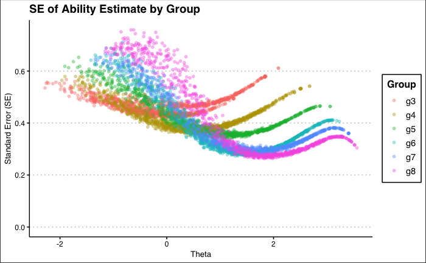

```r
tk07.abilities %>%
  filter(abs(ability_est) <= 6.0) %>%
  ggplot(., aes(x = ability_est, y = ability_est_se, color = group)) +
  geom_jitter(alpha = 0.2) +
  geom_point(alpha = 0.2, size = 1) +
  scale_y_continuous(limits = c(0, NA)) +
  labs(title = "SE of Ability Estimate by Group",
     x = "Theta",
     y = "Standard Error (SE)",
     color = "Group",
     fill = "Group") +
  theme_clean()
```

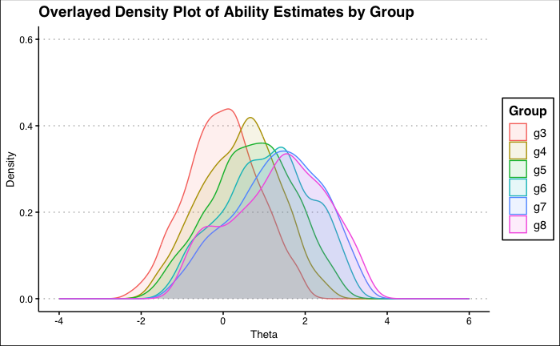

```r
tk07.abilities %>%
  filter(abs(ability_est) <= 6.0) %>%
ggplot(., aes(x = ability_est, color = as.factor(group), fill = as.factor(group))) +
  geom_density(alpha = 0.1) +  # Overlayed density plots with some transparency
  labs(title = "Overlayed Density Plot of Ability Estimates by Group",
       x = "Theta",
       y = "Density",
       color = "Group",
       fill = "Group") +
  scale_x_continuous(limits = c(-4, 6)) +
  scale_y_continuous(limits = c(0, 0.6)) +
  theme_clean()
```

#### Visualize Density, Info, and SE

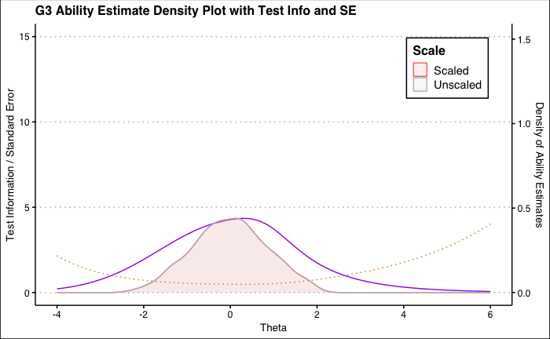

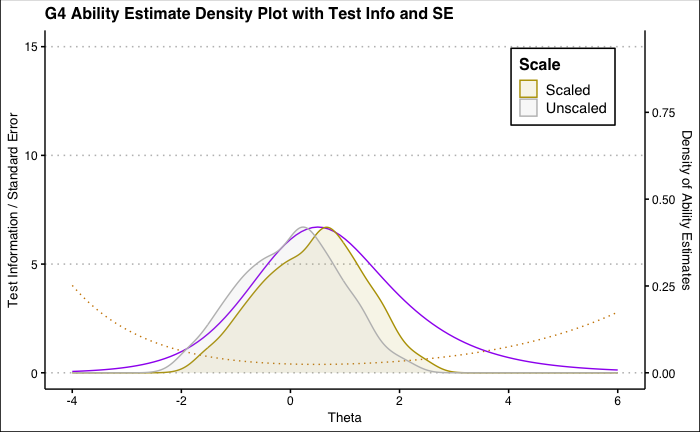

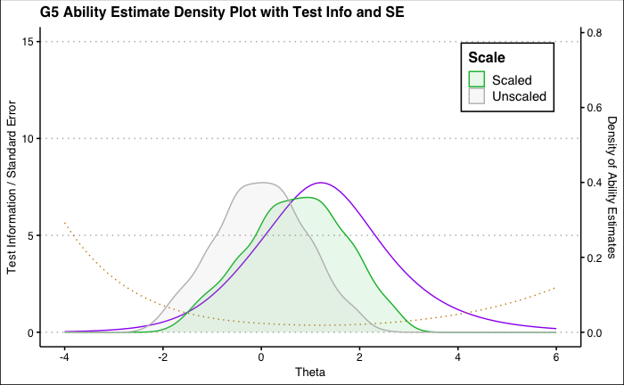

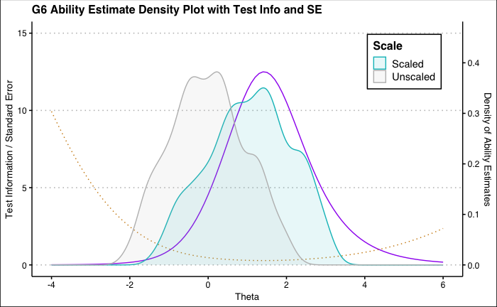

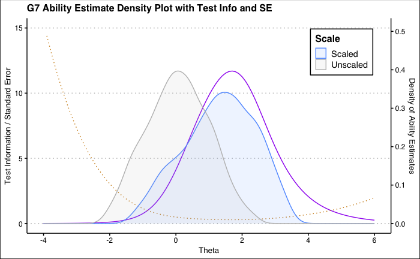

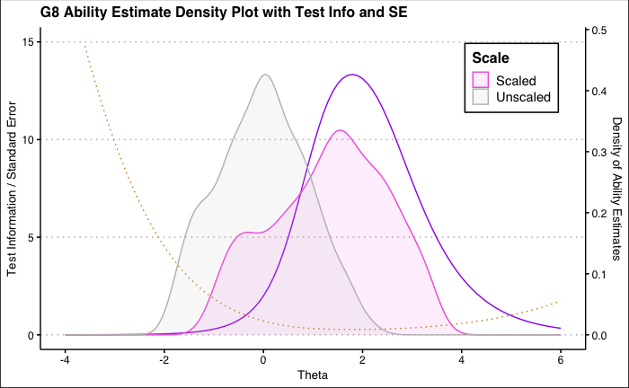

We can calculate the marginal reliability for every value of theta based on the test information function: marginal reliability = 1 - 1 / info(theta)

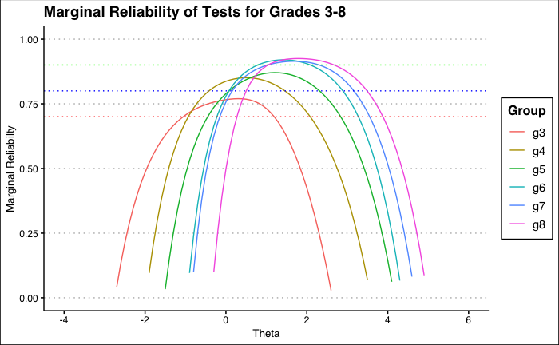

```r
tk07.relplot <- tk07.ti %>%
  pivot_longer(cols = ends_with("info"), names_to = "group", values_to = "info") %>%
  select(thetas, group, info) %>%
  mutate(group = gsub(".info","",group),
         reliability = 1 - 1/info) %>%
  ggplot() +
  geom_line(aes(x = thetas, y = reliability, color = group)) +
  scale_y_continuous(limits = c(0, 1)) +
  labs(title = "Marginal Reliability of Tests for Grades 3-8",
       x = "Theta",
       y = "Marginal Reliabilty",
       color = "Group",
       fill = "Group") +
  theme(plot.title = element_text(size = 12)) +
  geom_hline(yintercept = 0.7, color = "red", linetype = "dotted") +
  geom_hline(yintercept = 0.8, color = "blue", linetype = "dotted") +
  geom_hline(yintercept = 0.9, color = "green", linetype = "dotted") +
  theme_clean()

print(tk07.relplot) %>% suppressWarnings()
```

```r
for(i in 1:length(tk07.pars.out)) {
  params <- tk07.pars.out[[i]] %>%
    as.data.frame %>%
    setNames(c("a","b","c")) %>%
    mutate(group = grades[i]) %>%
    select(group, b)
  if(i == 1) {
    tk07.b.params <- params
  } else {
  tk07.b.params <- tk07.b.params %>%
    bind_rows(., params)
  }
}
```

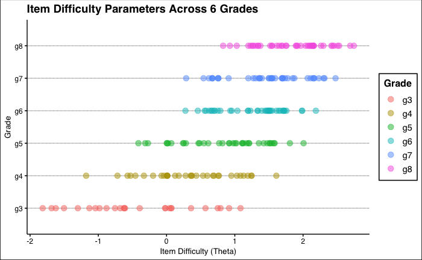

```r
tk07.b.params %>%
  mutate(item = seq(1:nrow(tk07.b.params)),
         group_position = as.numeric(gsub("g","",group)) - 2) %>%
ggplot(., aes(x = b, y = group_position)) +
  geom_hline(aes(yintercept = group_position), color = "gray80") +
  geom_point(aes(color = group), size = 3, alpha = 0.5) +
  scale_y_continuous(breaks = 1:6, labels = grades) +
  # scale_color_brewer(palette = "g3") +
  labs(title = "Item Difficulty Parameters Across 6 Grades",
       x = "Item Difficulty (Theta)",
       y = "Grade",
       color = "Grade") +
  theme_minimal() +
  theme(legend.position = "none",
        panel.grid.major.y = element_blank(),
        panel.grid.minor.y = element_blank()) +
  coord_cartesian(ylim = c(0.5, 6.5)) +
  theme_clean()
```

What next: 1. Scaling 2. Percentile ranks 3. Visualize the item parameters on the same scale. 4. Longitudinal data simulation

```r
constants
```

[output not shown]

# Investigate small ability estimates

```r
abilities %>%
  rownames_to_column("case") %>%
  mutate(case = as.numeric(case),
         case = ifelse(group == "x.new", case - 1000,
                       ifelse(group == "y", case - 2000,
                              case))) %>%
  filter(ability_est < -3) %>%
  arrange(ability_est)
```

```r
responses.y[c(754, 925),]
```

```r
responses.y[579,]

# est_ability(responses.y[579,],
#             as = pars.out$group2[,1],
#             bs = pars.out$group2[,2],
#             cs = pars.out$group2[,3])

abilities %>%
  ggplot(., aes(x = ability_est, color = group)) +
  geom_histogram()

x.abilities <- x.ability.old %>%
  rename_with(., ~paste0(.x, ".old")) %>%
  bind_cols(x.ability.new %>%
              rename_with(., ~paste0(.x, ".new")))
```

```r
# Create object with six groups (all dichotomous items)
pars <- TK07$pars
common <- TK07$common
cat <- list(rep(2,26),rep(2,34),rep(2,37),rep(2,40),rep(2,41),rep(2,43))
pm1 <- as.poly.mod(26)
pm2 <- as.poly.mod(34)
pm3 <- as.poly.mod(37)
pm4 <- as.poly.mod(40)
pm5 <- as.poly.mod(41)
pm6 <- as.poly.mod(43)
pm <- list(pm1, pm2, pm3, pm4, pm5, pm6)
x <- as.irt.pars(pars, common, cat, pm,
  grp.names=paste("grade",3:8,sep=""))
out <- plink(x)
summary(out)
constants <- link.con(out) # Extract linking constants

# Create an irt.pars object and a sep.pars object for two groups of
# nominal response model items. Compare non-symmetric and symmetric
# minimization. Note: This example may take a minute or two to run
## Not run:
pm <- as.poly.mod(60, "nrm", 1:60)
pars1 <- as.irt.pars(act.nrm$yr97, cat=rep(5,60), poly.mod=pm)
pars2 <- sep.pars(act.nrm$yr98, cat=rep(5,60), poly.mod=pm)
out <- plink(list(pars1, pars2), matrix(1:60,60,2))
out1 <- plink(list(pars1, pars2), matrix(1:60,60,2), symmetric=TRUE)
summary(out, descrip=TRUE)
summary(out1, descrip=TRUE)

## End(Not run)

# Compute linking constants for two groups with multiple-choice model
# item parameters. Rescale theta values and item parameters using
# the Haebara linking constants
# Note: This example may take a minute or two to run
## Not run:
theta <- rnorm(100) # In practice, estimated theta values would be used
pm <- as.poly.mod(60, "mcm", 1:60)
x <- as.irt.pars(act.mcm, common=matrix(1:60,60,2), cat=list(rep(6,60),
  rep(6,60)), poly.mod=list(pm,pm))
out <- plink(x, ability=list(theta,theta), rescale="HB")
pars.out <- link.pars(out)
ability.out <- link.ability(out)
summary(out, descrip=TRUE)

## End(Not run)

# Compute linking constants for two groups using mixed-format items and
# a mixed placement of common items. Compare calibrations with the
# inclusion or exclusion of NRM items. This example uses the dgn dataset.
pm1 <- as.poly.mod(55,c("drm","gpcm","nrm"),dgn$items$group1)
pm2 <- as.poly.mod(55,c("drm","gpcm","nrm"),dgn$items$group2)
x <- as.irt.pars(dgn$pars,dgn$common,dgn$cat,list(pm1,pm2))
# Run with the NRM common items included
out <- plink(x)
# Run with the NRM common items excluded
out1 <- plink(x,exclude="nrm")
summary(out)
summary(out1)


# Compute linking constants for six groups using mixed-format items and
# a mixed placement of common items. This example uses the reading dataset.
# See the information on the dataset for an interpretation of the output.
pm1 <- as.poly.mod(41, c("drm", "gpcm"), reading$items[[1]])
pm2 <- as.poly.mod(70, c("drm", "gpcm"), reading$items[[2]])
pm3 <- as.poly.mod(70, c("drm", "gpcm"), reading$items[[3]])
pm4 <- as.poly.mod(70, c("drm", "gpcm"), reading$items[[4]])
pm5 <- as.poly.mod(72, c("drm", "gpcm"), reading$items[[5]])
pm6 <- as.poly.mod(71, c("drm", "gpcm"), reading$items[[6]])
pm <- list(pm1, pm2, pm3, pm4, pm5, pm6)
x <- as.irt.pars(reading$pars, reading$common, reading$cat, pm, base.grp=4)
out <- plink(x)
summary(out)


###### Multidimensional Examples ######
# Reckase Chapter 9
pm <- as.poly.mod(80, "drm", list(1:80))
x <- as.irt.pars(reckase9$pars, reckase9$common,
  list(rep(2,80),rep(2,80)), list(pm,pm), dimensions=2)
# Compute constants using the least squares method and
# the orthongal rotation with variable dilation.
# Rescale the item parameters using the LS method
out <- plink(x, dilation="orth.vd", rescale="LS")
summary(out, descrip=TRUE)
# Extract the rescaled item parameters
pars.out <- link.pars(out)

# Compute constants using an oblique Procrustes method
# Display output and descriptives
out <- plink(x, dilation="oblique")
summary(out, descrip=TRUE)

# Compute constants using and orthogonal rotation with
# a fixed dilation parameter
# Rescale the item parameters and ability estimates
# using the "HB" and "LS" methods.
# Display the optimization iterations
ability <- matrix(rnorm(40),20,2)
out <- plink(x, method=c("HB","LS"), dilation="orth.fd",
   rescale="HB", ability=list(ability,ability),
   control=list(trace=1,rel.tol=0.001))
summary(out)
# Extract rescaled ability estimates
ability.out <- out$ability


# Compute linking constants for two groups using mixed-format items
# modeled with the M3PL and MGPCM. Only compute constants using the
# orth.vd dilation.
pm <- as.poly.mod(60,c("drm","gpcm"), list(c(1:60)[md.mixed$cat==2],
  c(1:60)[md.mixed$cat>2]))
x <- as.irt.pars(md.mixed$pars, matrix(1:60,60,2),
  list(md.mixed$cat, md.mixed$cat),
  list(pm, pm), dimensions=4, grp.names=c("Form.X","Form.Y"))
out <- plink(x,dilation="orth.vd")
summary(out, descrip=TRUE)


# Illustration of construct shift and how to specify common dimensions
pm <- as.poly.mod(80, "drm", list(1:80))
pars <- cbind(round(runif(80),2),reckase9$pars[[1]])
x <- as.irt.pars(list(pars,reckase9$pars[[2]]), reckase9$common,
list(rep(2,80),rep(2,80)), list(pm,pm), dimensions=c(3,2))
dim.order <- matrix(c(1,2,3,NA,1,2),2,3,byrow=TRUE)
out <- plink(x, dilation="oblique", dim.order=dim.order, rescale="LS")
summary(out)
pars.out <- link.pars(out)
```